# An Introduction to spmodel

Michael Dumelle, Matt Higham, and Jay M. Ver Hoef

# 1 Introduction

The `spmodel` **R** package is used to fit and summarize spatial models and make predictions at unobserved locations (Kriging). This vignette provides an overview of basic features in `spmodel`. We load `spmodel` by running

```r
library(spmodel)
```

If you use `spmodel` in a formal publication or report, please cite it. Citing `spmodel` lets us devote more resources to it in the future. We view the `spmodel` citation by running

```r
citation(package = "spmodel")
```

```
#>
#>   Dumelle M, Higham M, Ver Hoef JM (2023). spmodel: Spatial statistical
#>   modeling and prediction in R. PLOS ONE 18(3): e0282524.
#>   https://doi.org/10.1371/journal.pone.0282524
#>
#> A BibTeX entry for LaTeX users is
#>
#>   @Article{,
#>     title = {{spmodel}: Spatial statistical modeling and prediction in {R}},
#>     author = {Michael Dumelle and Matt Higham and Jay M. {Ver Hoef}},
#>     journal = {PLOS ONE},
#>     year = {2023},
#>     volume = {18},
#>     number = {3},
#>     pages = {1--32},
#>     doi = {10.1371/journal.pone.0282524},
#>     url = {https://doi.org/10.1371/journal.pone.0282524},
#>   }
```

This vignette comes with the installed version of `spmodel` (accessible via `browseVignettes(package = "spmodel")`. Eight more in-depth vignettes (i.e., articles) are available only on the `spmodel` website; we briefly describe each below.

# 2 Website-Only Vignettes

The following vignettes (i.e., articles) are not installed alongside `spmodel` package but are available on our website at https://usepa.github.io/spmodel/:

- [A Detailed Guide to `spmodel`](https://usepa.github.io/spmodel/articles/guide.html): A deep walkthrough of `spmodel`, covering some spatial modeling background, the available estimation methods, prediction, and advanced features like random effects, partition factors, anisotropy, and big data approaches.
- [Spatial Generalized Linear Models in `spmodel`](https://usepa.github.io/spmodel/articles/SPGLMs.html): Fitting, summarizing, and predicting with `spglm()` and `spgautor()` for binary, proportion, count, and skewed spatial data.
- [Using `emmeans` to Estimate Marginal Means of `spmodel` Objects](https://usepa.github.io/spmodel/articles/emmeans.html): Estimating and contrasting marginal means (i.e., least-squares means) for `spmodel` model objects using the `emmeans` package.
- [Block Prediction (i.e., Block Kriging) in `spmodel`](https://usepa.github.io/spmodel/articles/block.html): Predicting the average (or total) value of a response variable across a geographic region rather than at a single location.
- [Simulating Spatial Data in `spmodel`](https://usepa.github.io/spmodel/articles/simulation.html): Simulating spatially correlated data with `sprnorm()` and related functions.
- [Conditional Simulation in `spmodel`](https://usepa.github.io/spmodel/articles/conditional.html): Generating many plausible random samples of model parameters and `newdata` using `conditional()`, especially useful for quantifying uncertainty in nonlinear functions of model parameters and predictions.
- [The Spatial Decorrelation Transformation for Machine Learning Models](https://usepa.github.io/spmodel/articles/decorrelate.html): Account for spatial dependence in machine learning algorithms (e.g., random forests, gradient boosting) using `decorrelate()` and related functions.
- [Technical Details](https://usepa.github.io/spmodel/articles/technical.html): The technical details behind every relevant function in `spmodel`.

Additionally, there are two workbooks that have accompanied recent `spmodel` workshops:

1. 2024 Society for Freshwater Science Conference: “Spatial Analysis and Statistical Modeling with R and `spmodel` available at https://usepa.github.io/spworkshop.sfs24/
2. 2023 Spatial Statistics Conference: `spmodel` workshop available at https://usepa.github.io/spmodel.spatialstat2023/

# 3 The Data

Many of the data sets we use in this vignette are `sf` objects. `sf` objects are data frames (or tibbles) with a special structure that stores spatial information. They are built using the `sf` (Pebesma 2018) package, which is installed alongside `spmodel`. We will use six data sets throughout this vignette:

- `moss`: An `sf` object with heavy metal concentrations in Alaska.
- `sulfate`: An `sf` object with sulfate measurements in the conterminous United States.
- `sulfate_preds`: An `sf` object with locations at which to predict sulfate measurements in the conterminous United States.
- `caribou`: A `tibble` (a special `data.frame`) for a caribou foraging experiment in Alaska.
- `moose`: An `sf` object with moose measurements in Alaska.
- `moose_preds`: An `sf` object with locations at which to predict moose measurements in Alaska.

We will create visualizations using ggplot2 (Wickham 2016), which we load by running

```r
library(ggplot2)
```

ggplot2 is only installed alongside `spmodel` when `dependencies = TRUE` in `install.packages()`, so check that it is installed before reproducing any visualizations in this vignette.

# 4 Spatial Linear Models

Spatial linear models for a quantitative response vector $\mathbf{y}$ have spatially dependent random errors and are often parameterized as

$$\mathbf{y} = \mathbf{X} \boldsymbol{\beta} + \boldsymbol{\tau} +
\boldsymbol{\epsilon},$$

where $\mathbf{X}$ is a matrix of explanatory variables (usually including a column of 1’s for an intercept), $\boldsymbol{\beta}$ is a vector of fixed effects that describe the average impact of $\mathbf{X}$ on $\mathbf{y}$, $\boldsymbol{\tau}$ is a vector of spatially dependent (correlated) random errors, and $\boldsymbol{\epsilon}$ is a vector of spatially independent (uncorrelated) random errors. The spatial dependence of $\boldsymbol{\tau}$ is explicitly specified using a spatial covariance function that incorporates the variance of $\boldsymbol{\tau}$, often called the partial sill, and a range parameter that controls the behavior of the spatial covariance. The variance of $\boldsymbol{\epsilon}$ is often called the nugget.

Spatial linear models are fit in `spmodel` for point-referenced and areal data. Data are point-referenced when the elements in $\mathbf{y}$ are observed at point-locations indexed by x-coordinates and y-coordinates on a spatially continuous surface with an infinite number of locations. The `splm()` function is used to fit spatial linear models for point-referenced data (these are often called geostatistical models). Data are areal when the elements in $\mathbf{y}$ are observed as part of a finite network of polygons whose connections are indexed by a neighborhood structure. For example, the polygons may represent counties in a state who are neighbors if they share at least one boundary. The `spautor()` function is used to fit spatial linear models for areal data (these are often called spatial autoregressive models). This vignette focuses on spatial linear models for point-referenced data, though `spmodel`’s other vignettes discuss spatial linear models for areal data.

The `splm()` function has similar syntax and output as the commonly used `lm()` function used to fit non-spatial linear models. `splm()` generally requires at least three arguments:

- `formula`: a formula that describes the relationship between the response variable and explanatory variables.
  - `formula` uses the same syntax as the `formula` argument in `lm()`
- `data`: a `data.frame` or `sf` object that contains the response variable, explanatory variables, and spatial information.
- `spcov_type`: the spatial covariance type (`"exponential"`, `"spherical"`, `"matern"`, etc).

If `data` is an `sf` object, the coordinate information is taken from the object’s geometry. If `data` is a `data.frame` (or `tibble`), then `xcoord` and `ycoord` are required arguments to `splm()` that specify the columns in `data` representing the x-coordinates and y-coordinates, respectively. `spmodel` uses the spatial coordinates “as-is,” meaning that `spmodel` does not perform any projections. To project your data or change the coordinate reference system, use `sf::st_transform()`. If an `sf` object with polygon geometries is given to `splm()`, the centroids of each polygon are used to fit the spatial linear model.

Next we show the basic features and syntax of `splm()` using the Alaskan `moss` data. We study the impact of log distance to the road (`log_dist2road`) on log zinc concentration (`log_Zn`). We view the first few rows of the `moss` data by running

```r
moss
```

```
#> Simple feature collection with 365 features and 9 fields
#> Geometry type: POINT
#> Dimension:     XY
#> Bounding box:  xmin: -445884.1 ymin: 1929616 xmax: -383656.8 ymax: 2061414
#> Projected CRS: NAD83 / Alaska Albers
#> # A tibble: 365 × 10
#>    sample field_dup lab_rep year  sideroad log_dist2road dist2road log_Zn    Zn
#>    <fct>  <fct>     <fct>   <fct> <fct>            <dbl>     <dbl>  <dbl> <dbl>
#>  1 001PR  1         1       2001  N                 2.68     14.6    7.33 1528.
#>  2 001PR  1         2       2001  N                 2.68     14.6    7.38 1603.
#>  3 002PR  1         1       2001  N                 2.54     12.6    7.58 1968.
#>  4 003PR  1         1       2001  N                 2.97     19.6    7.63 2060.
#>  5 004PR  1         1       2001  N                 2.72     15.2    7.26 1423.
#>  6 005PR  1         1       2001  N                 2.76     15.8    7.65 2093.
#>  7 006PR  1         1       2001  S                 2.30      9.99   7.59 1971.
#>  8 007PR  1         1       2001  N                 2.78     16.1    7.16 1282.
#>  9 008PR  1         1       2001  N                 2.93     18.7    7.19 1329.
#> 10 009PR  1         1       2001  N                 2.79     16.3    8.07 3207.
#> # ℹ 355 more rows
#> # ℹ 1 more variable: geometry <POINT [m]>
```

We can visualize the distribution of log zinc concentration (`log_Zn`) by running

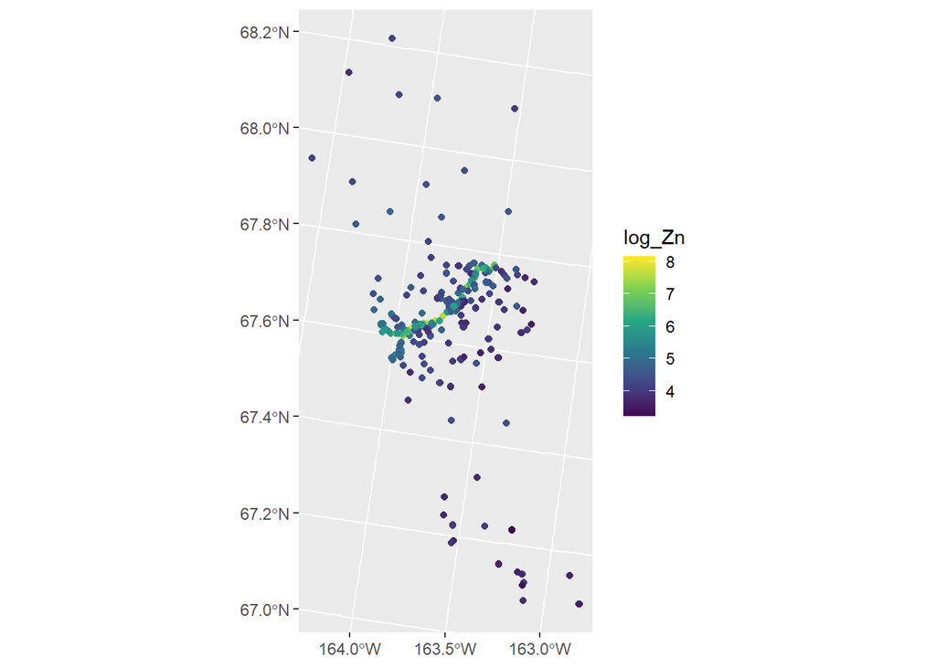

```r
ggplot(moss, aes(color = log_Zn)) +
  geom_sf() +
  scale_color_viridis_c()
```

Log zinc concentration appears highest in the middle of the spatial domain, which has a road running through it. We fit a spatial linear model regressing log zinc concentration on log distance to the road using an exponential spatial covariance function by running

```r
spmod <- splm(log_Zn ~ log_dist2road, data = moss, spcov_type = "exponential")
```

The estimation method is specified via the `estmethod` argument, which has a default value of `"reml"` for restricted maximum likelihood. Other estimation methods are `"ml"` for maximum likelihood, `"sv-wls"` for semivariogram weighted least squares, and `"sv-cl"` for semivariogram composite likelihood.

Printing `spmod` shows the function call, the estimated fixed effect coefficients, and the estimated spatial covariance parameters. `de` is the estimated variance of $\boldsymbol{\tau}$ (the spatially dependent random error), `ie` is the estimated variance of $\boldsymbol{\epsilon}$ (the spatially independent random error), and `range` is the range parameter.

```r
print(spmod)
```

```
#>
#> Call:
#> splm(formula = log_Zn ~ log_dist2road, data = moss, spcov_type = "exponential")
#>
#>
#> Coefficients (fixed):
#>   (Intercept)  log_dist2road
#>         9.758         -0.562
#>
#>
#> Coefficients (exponential spatial covariance):
#>        de         ie      range
#> 3.499e-01  7.973e-02  8.154e+03
```

Next we show how to obtain more detailed summary information from the fitted model.

## 4.1 Model Summaries

We summarize the fitted model by running

```r
summary(spmod)
```

```
#>
#> Call:
#> splm(formula = log_Zn ~ log_dist2road, data = moss, spcov_type = "exponential")
#>
#> Residuals:
#>     Min      1Q  Median      3Q     Max
#> -2.6735 -1.3575 -0.8082 -0.2469  1.1307
#>
#> Coefficients (fixed):
#>                Estimate Std. Error        df t value Pr(>|t|)
#> (Intercept)     9.75831    0.25007  34.46642   39.02   <2e-16 ***
#> log_dist2road  -0.56204    0.02009 272.99883  -27.98   <2e-16 ***
#> ---
#> Signif. codes:  0 '***' 0.001 '**' 0.01 '*' 0.05 '.' 0.1 ' ' 1
#>
#> Pseudo R-squared: 0.6832
#>
#> Coefficients (exponential spatial covariance):
#>        de        ie     range
#> 3.499e-01 7.973e-02 8.154e+03
```

In the remainder of this subsection, we describe the broom (Robinson et al. 2021) functions `tidy()`, `glance()` and `augment()`. `tidy()` tidies coefficient output in a convenient `tibble`, `glance()` glances at model-fit statistics, and `augment()` augments the data with fitted model diagnostics.

We tidy the fixed effects by running

```r
tidy(spmod)
```

```
#> # A tibble: 2 × 6
#>   term          estimate std.error    df statistic  p.value
#>   <chr>            <dbl>     <dbl> <dbl>     <dbl>    <dbl>
#> 1 (Intercept)      9.76     0.250   34.5      39.0 4.12e-30
#> 2 log_dist2road   -0.562    0.0201 273.      -28.0 3.58e-82
```

We glance at the model-fit statistics by running

```r
glance(spmod)
```

```
#> # A tibble: 1 × 10
#>       n     p  npar value   AIC  AICc   BIC logLik deviance pseudo.r.squared
#>   <int> <dbl> <int> <dbl> <dbl> <dbl> <dbl>  <dbl>    <dbl>            <dbl>
#> 1   365     2     3  367.  373.  373.  385.  -184.     363.            0.683
```

The columns of this `tibble` represent:

- `n`: The sample size
- `p`: The number of fixed effects (linearly independent columns in $\mathbf{X}$)
- `npar`: The number of estimated covariance parameters
- `value`: The value of the minimized objective function used when fitting the model
- `AIC`: The Akaike Information Criterion (AIC)
- `AICc`: The AIC with a small sample size correction
- `BIC`: The Bayesian Information Criterion (BIC)
- `logLik`: The log-likelihood
- `deviance`: The deviance
- `pseudo.r.squared`: The pseudo r-squared

The `glances()` function can be used to glance at multiple models at once. Suppose we wanted to compare the current model, which uses an exponential spatial covariance, to a new model without spatial covariance (equivalent to a model fit using `lm()`). We do this using `glances()` by running

```r
lmod <- splm(log_Zn ~ log_dist2road, data = moss, spcov_type = "none")
glances(spmod, lmod)
```

```
#> # A tibble: 2 × 11
#>   model     n     p  npar value   AIC  AICc   BIC logLik deviance
#>   <chr> <int> <dbl> <int> <dbl> <dbl> <dbl> <dbl>  <dbl>    <dbl>
#> 1 spmod   365     2     3  367.  373.  373.  385.  -184.     363.
#> 2 lmod    365     2     1  632.  634.  634.  638.  -316.     363.
#> # ℹ 1 more variable: pseudo.r.squared <dbl>
```

The much lower AIC and AICc for the spatial linear model indicates it is a much better fit to the data. Outside of `glance()` and `glances()`, the functions `AIC()`, `AICc()`, `BIC()` `logLik()`, `deviance()`, and `pseudoR2()` are available to compute the relevant statistics.

We augment the data with diagnostics by running

```r
augment(spmod)
```

```
#> Simple feature collection with 365 features and 7 fields
#> Geometry type: POINT
#> Dimension:     XY
#> Bounding box:  xmin: -445884.1 ymin: 1929616 xmax: -383656.8 ymax: 2061414
#> Projected CRS: NAD83 / Alaska Albers
#> # A tibble: 365 × 8
#>    log_Zn log_dist2road .fitted .resid   .hat .cooksd .std.resid
#>  *  <dbl>         <dbl>   <dbl>  <dbl>  <dbl>   <dbl>      <dbl>
#>  1   7.33          2.68    8.25 -0.920 0.0200 0.0142       1.18
#>  2   7.38          2.68    8.25 -0.873 0.0200 0.0186       1.35
#>  3   7.58          2.54    8.33 -0.747 0.0226 0.00494      0.653
#>  4   7.63          2.97    8.09 -0.456 0.0198 0.0306       1.74
#>  5   7.26          2.72    8.23 -0.970 0.0215 0.129        3.43
#>  6   7.65          2.76    8.21 -0.560 0.0284 0.0522       1.89
#>  7   7.59          2.30    8.46 -0.878 0.0299 0.0585       1.95
#>  8   7.16          2.78    8.20 -1.04  0.0334 0.00335      0.441
#>  9   7.19          2.93    8.11 -0.919 0.0377 0.0311       1.26
#> 10   8.07          2.79    8.19 -0.116 0.0314 0.00877      0.736
#> # ℹ 355 more rows
#> # ℹ 1 more variable: geometry <POINT [m]>
```

The columns of this tibble represent:

- `log_Zn`: The log zinc concentration.
- `log_dist2road`: The log distance to the road.
- `.fitted`: The fitted values (the estimated mean given the explanatory variable values).
- `.resid`: The residuals (the response minus the fitted values).
- `.hat`: The leverage (hat) values.
- `.cooksd`: The Cook’s distance
- `.std.resid`: Standardized residuals
- `geometry`: The spatial information in the `sf` object.

By default, `augment()` only returns the variables in the data used by the model. All variables from the original data are returned by setting `drop = FALSE`. Many of these model diagnostics can be visualized by running `plot(spmod)`. We can learn more about `plot()` in `spmodel` by running `help("plot.spmodel", "spmodel")`.

## 4.2 Prediction (Kriging)

Commonly a goal of a data analysis is to make predictions at unobserved locations. In spatial contexts, prediction is often called Kriging. Next we use the `sulfate` data to build a spatial linear model of sulfate measurements in the conterminous United States with the goal of making sulfate predictions (Kriging) for the unobserved locations in `sulfate_preds`.

We visualize the distribution of `sulfate` by running

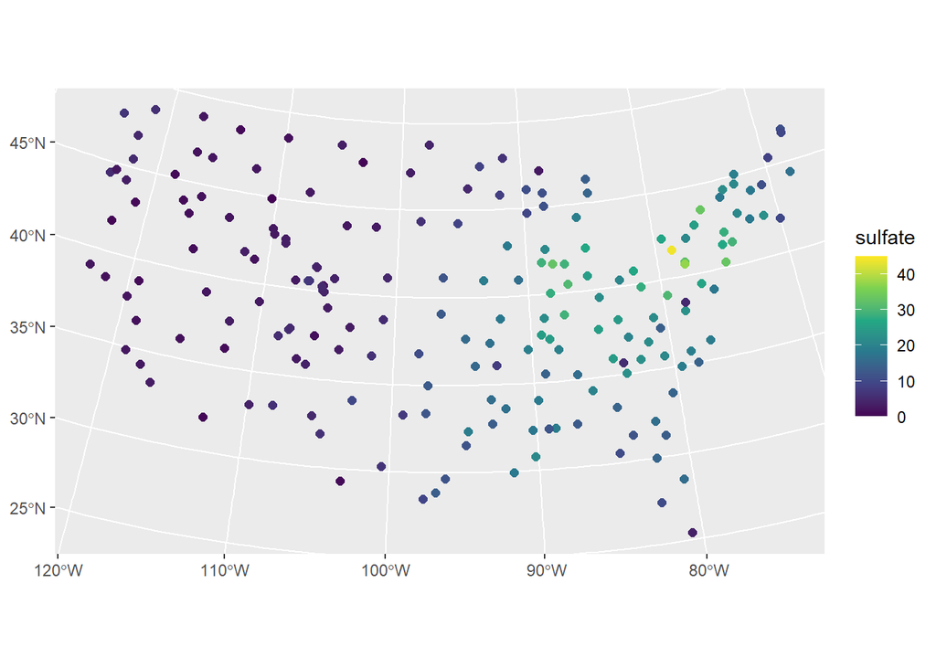

```r
ggplot(sulfate, aes(color = sulfate)) +
  geom_sf(size = 2) +
  scale_color_viridis_c(limits = c(0, 45))
```

We fit a spatial linear model regressing sulfate on an intercept using a spherical spatial covariance function by running

```r
sulfmod <- splm(sulfate ~ 1, data = sulfate, spcov_type =  "spherical")
```

We make predictions at the locations in `sulfate_preds` and store them as a new variable called `preds` in the `sulfate_preds` data set by running

```r
sulfate_preds$preds <- predict(sulfmod, newdata = sulfate_preds)
```

We visualize these predictions by running

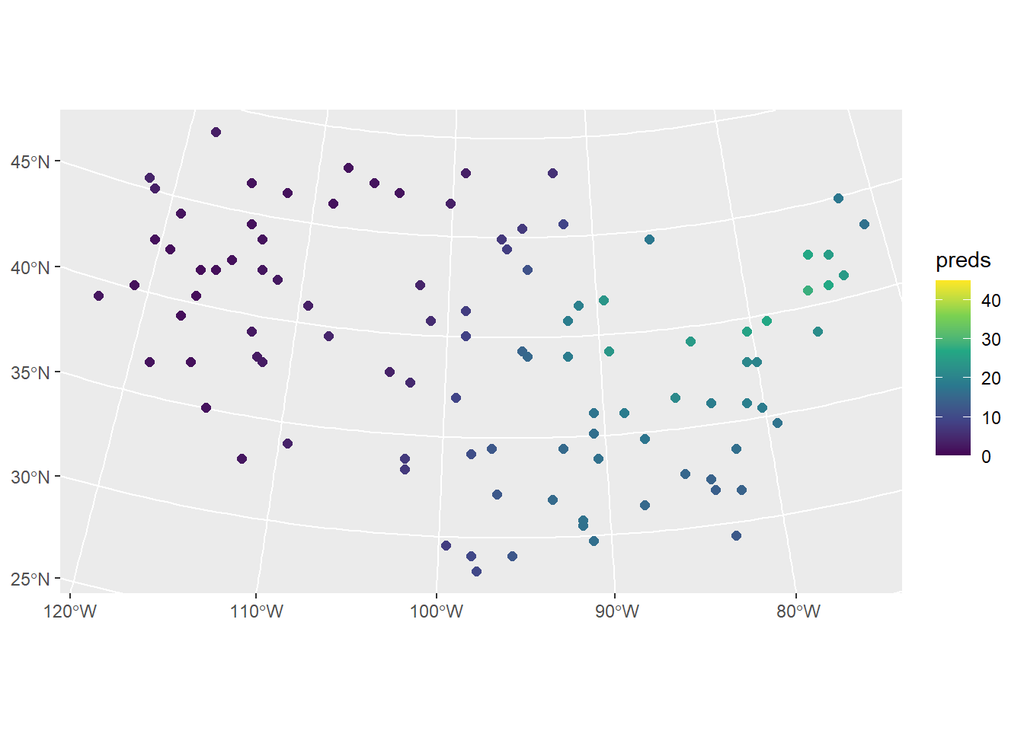

```r
ggplot(sulfate_preds, aes(color = preds)) +
  geom_sf(size = 2) +
  scale_color_viridis_c(limits = c(0, 45))
```

```r
sulfate_preds$preds <- NULL
```

While `augment()` was previously used to augment the original data with model diagnostics, it can also be used to augment the `newdata` data with predictions:

```r
augment(sulfmod, newdata = sulfate_preds)
```

```
#> Simple feature collection with 100 features and 1 field
#> Geometry type: POINT
#> Dimension:     XY
#> Bounding box:  xmin: -2283774 ymin: 582930.5 xmax: 1985906 ymax: 3037173
#> Projected CRS: NAD83 / Conus Albers
#> # A tibble: 100 × 2
#>    .fitted            geometry
#>  *   <dbl>         <POINT [m]>
#>  1    1.36  (-1771413 1752976)
#>  2   24.5    (1018112 1867127)
#>  3    8.94 (-291256.8 1553212)
#>  4   16.4    (1274293 1267835)
#>  5    4.86 (-547437.6 1638825)
#>  6   26.8    (1445080 1981278)
#>  7    3.07  (-1629090 3037173)
#>  8   14.3    (1302757 1039534)
#>  9    1.51  (-1429838 2523494)
#> 10   14.4    (1131970 1096609)
#> # ℹ 90 more rows
```

Here `.fitted` represents the predictions.

Confidence intervals for the mean response or prediction intervals for the predicted response can be obtained by specifying the `interval` argument in `predict()` and `augment()`:

```r
augment(sulfmod, newdata = sulfate_preds, interval = "prediction")
```

```
#> Simple feature collection with 100 features and 3 fields
#> Geometry type: POINT
#> Dimension:     XY
#> Bounding box:  xmin: -2283774 ymin: 582930.5 xmax: 1985906 ymax: 3037173
#> Projected CRS: NAD83 / Conus Albers
#> # A tibble: 100 × 4
#>    .fitted .lower .upper            geometry
#>  *   <dbl>  <dbl>  <dbl>         <POINT [m]>
#>  1    1.36  -6.64   9.37  (-1771413 1752976)
#>  2   24.5   17.0   32.0    (1018112 1867127)
#>  3    8.94   1.06  16.8  (-291256.8 1553212)
#>  4   16.4    8.68  24.2    (1274293 1267835)
#>  5    4.86  -2.82  12.6  (-547437.6 1638825)
#>  6   26.8   19.3   34.2    (1445080 1981278)
#>  7    3.07  -4.83  11.0   (-1629090 3037173)
#>  8   14.3    6.79  21.8    (1302757 1039534)
#>  9    1.51  -6.30   9.33  (-1429838 2523494)
#> 10   14.4    6.73  22.0    (1131970 1096609)
#> # ℹ 90 more rows
```

By default, `predict()` and `augment()` compute 95% intervals, though this can be changed using the `level` argument.

While the fitted model in this example only used an intercept, the same code is used for prediction with fitted models having explanatory variables. If explanatory variables were used to fit the model, the same explanatory variables must be included in `newdata` with the same names they have in `data`. If `data` is a `data.frame`, coordinates must be included in `newdata` with the same names as they have in `data`. If `data` is an `sf` object, coordinates must be included in `newdata` with the same geometry name as they have in `data`. When using projected coordinates, the projection for `newdata` should be the same as the projection for `data`.

## 4.3 An Additional Example

We now use the `caribou` data from a foraging experiment conducted in Alaska to show an application of `splm()` to data stored in a `tibble` (`data.frame`) instead of an `sf` object. In `caribou`, the x-coordinates are stored in the `x` column and the y-coordinates are stored in the `y` column. We view the first few rows of `caribou` by running

```r
caribou
```

```
#> # A tibble: 30 × 5
#>    water tarp      z     x     y
#>    <fct> <fct> <dbl> <dbl> <dbl>
#>  1 Y     clear  2.42     1     6
#>  2 Y     shade  2.44     2     6
#>  3 Y     none   1.81     3     6
#>  4 N     clear  1.97     4     6
#>  5 N     shade  2.38     5     6
#>  6 Y     none   2.22     1     5
#>  7 N     clear  2.10     2     5
#>  8 Y     clear  1.80     3     5
#>  9 Y     shade  1.96     4     5
#> 10 Y     none   2.10     5     5
#> # ℹ 20 more rows
```

We fit a spatial linear model regressing nitrogen percentage (`z`) on water presence (`water`) and tarp cover (`tarp`) by running

```r
cariboumod <- splm(z ~ water + tarp, data = caribou,
                   spcov_type = "exponential", xcoord = x, ycoord = y)
```

An analysis of variance can be conducted to assess the overall impact of the `tarp` variable, which has three levels (clear, shade, and none), and the `water` variable, which has two levels (water and no water). We perform an analysis of variance by running

```r
anova(cariboumod)
```

```
#> Analysis of Variance Table
#>
#> Response: z
#>             NumDF  DenDF F value   Pr(>F)
#> (Intercept)     1     NA 45.5642       NA
#> water           1 22.396  1.6738 0.208929
#> tarp            2 19.525  7.7293 0.003369 **
#> ---
#> Signif. codes:  0 '***' 0.001 '**' 0.01 '*' 0.05 '.' 0.1 ' ' 1
```

There seems to be significant evidence that at least one tarp cover impacts nitrogen. Note that, like in `summary()`, these p-values are associated with a hypothesis test that uses Satterthwaite denominator degrees of freedom by default when the sample size is small (here, an F-test), and an asymptotic Chi-squared test otherwise.

# 5 Spatial Generalized Linear Models

When building spatial linear models, the response vector $\mathbf{y}$ is typically assumed Gaussian (given $\mathbf{X}$). Relaxing this assumption on the distribution of $\mathbf{y}$ yields a rich class of spatial generalized linear models that can describe binary data, proportion data, count data, and skewed data. Spatial generalized linear models are parameterized as
$$g(\boldsymbol{\mu}) = \boldsymbol{\eta} = \mathbf{X} \boldsymbol{\beta}
+ \boldsymbol{\tau} + \boldsymbol{\epsilon},$$
where $g(\cdot)$ is called a link function, $\boldsymbol{\mu}$ is the mean of $\mathbf{y}$, and the remaining terms $\mathbf{X}$, $\boldsymbol{\beta}$, $\boldsymbol{\tau}$, $\boldsymbol{\epsilon}$ represent the same quantities as for the spatial linear models. The link function, $g(\cdot)$, “links” a function of $\boldsymbol{\mu}$ to the linear term $\boldsymbol{\eta}$, denoted here as $\mathbf{X} \boldsymbol{\beta} + \boldsymbol{\tau} + \boldsymbol{\epsilon}$, which is familiar from spatial linear models. Note that the linking of $\boldsymbol{\mu}$ to $\boldsymbol{\eta}$ applies element-wise to each vector. Each link function $g(\cdot)$ has a corresponding inverse link function, $g^{-1}(\cdot)$. The inverse link function “links” a function of $\boldsymbol{\eta}$ to $\boldsymbol{\mu}$. Notice that for spatial generalized linear models, we are not modeling $\mathbf{y}$ directly as we do for spatial linear models, but rather we are modeling a function of the mean of $\mathbf{y}$. Also notice that $\boldsymbol{\eta}$ is unconstrained but $\boldsymbol{\mu}$ is usually constrained in some way (e.g., positive). Next we discuss the specific distributions and link functions used in `spmodel`.

`spmodel` allows fitting of spatial generalized linear models when $\mathbf{y}$ is a binomial (or Bernoulli), beta, Poisson, negative binomial, gamma, or inverse Gaussian random vector. For binomial and beta $\mathbf{y}$, the logit link function is defined as $g(\boldsymbol{\mu}) = \ln(\frac{\boldsymbol{\mu}}{1 - \boldsymbol{\mu}}) = \boldsymbol{\eta}$, and the inverse logit link function is defined as $g^{-1}(\boldsymbol{\eta}) = \frac{\exp(\boldsymbol{\eta})}{1 + \exp(\boldsymbol{\eta})} = \boldsymbol{\mu}$. For Poisson, negative binomial, gamma, and inverse Gaussian $\mathbf{y}$, the log link function is defined as $g(\boldsymbol{\mu}) = \ln(\boldsymbol{\mu}) = \boldsymbol{\eta}$, and the inverse log link function is defined as $g^{-1}(\boldsymbol{\eta}) = \exp(\boldsymbol{\eta}) = \boldsymbol{\mu}$.

As with spatial linear models, spatial generalized linear models are fit in `spmodel` for point-referenced and areal data. The `spglm()` function is used to fit spatial generalized linear models for point-referenced data, and the `spgautor()` function is used to fit spatial generalized linear models for areal data. Though this vignette focuses on point-referenced data, `spmodel`’s other vignettes discuss spatial generalized linear models for areal data.

The `spglm()` function is quite similar to the `splm()` function, though one additional argument is required:

- `family`: the generalized linear model family (i.e., the distribution of $\mathbf{y}$). `family` can be `binomial`, `beta`, `poisson`, `nbinomial`, `Gamma`, or `inverse.gaussian`.
  - `family` uses similar syntax as the `family` argument in `glm()`.
  - One difference between `family` in `spglm()` compared to `family` in `glm()` is that the link function is fixed in `spglm()`.

Next we show the basic features and syntax of `spglm()` using the `moose` data. We study the impact of elevation (`elev`) on the presence of moose (`presence`) observed at a site location in Alaska. `presence` equals one if at least one moose was observed at the site and zero otherwise. We view the first few rows of the `moose` data by running

```r
moose
```

[output not shown]

We can visualize the distribution of moose presence by running

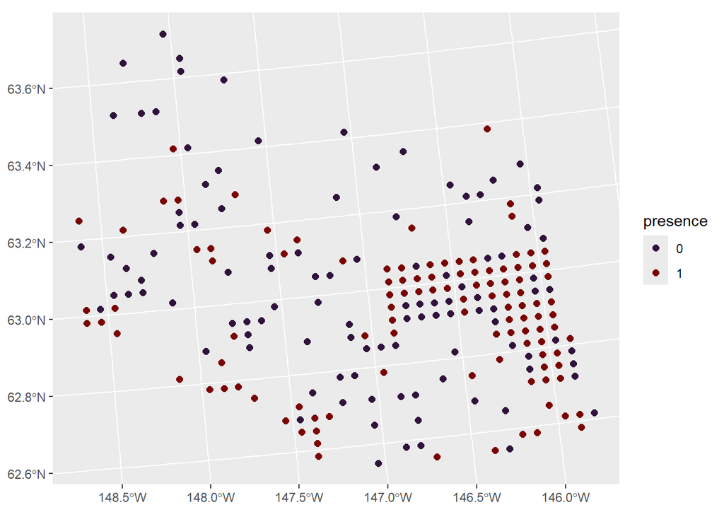

```r
ggplot(moose, aes(color = presence)) +
  scale_color_viridis_d(option = "H") +
  geom_sf(size = 2)
```

One example of a generalized linear model is a binomial (e.g., logistic) regression model. Binomial regression models are often used to model presence data such as this. To quantify the relationship between moose presence and elevation, we fit a spatial binomial regression model (a specific spatial generalized linear model) by running

```r
binmod <- spglm(presence ~ elev, family = "binomial",
                data  = moose, spcov_type = "exponential")
```

The estimation method is specified via the `estmethod` argument, which has a default value of `"reml"` for restricted maximum likelihood. The other estimation method is `"ml"` for maximum likelihood.

Printing `binmod` shows the function call, the estimated fixed effect coefficients (on the link scale), the estimated spatial covariance parameters, and a dispersion parameter. The dispersion parameter is estimated for some spatial generalized linear models and changes the mean-variance relationship of $\mathbf{y}$. For binomial regression models, the dispersion parameter is not estimated and is always fixed at one.

```r
print(binmod)
```

```
#>
#> Call:
#> spglm(formula = presence ~ elev, family = "binomial", data = moose,
#>     spcov_type = "exponential")
#>
#>
#> Coefficients (fixed):
#> (Intercept)         elev
#>   -0.897017     0.002442
#>
#>
#> Coefficients (exponential spatial covariance):
#>        de         ie      range
#> 4.063e+00  4.263e-04  3.325e+04
#>
#>
#> Coefficients (Dispersion for binomial family):
#> dispersion
#>          1
```

## 5.1 Model Summaries

We summarize the fitted model by running

```r
summary(binmod)
```

```
#>
#> Call:
#> spglm(formula = presence ~ elev, family = "binomial", data = moose,
#>     spcov_type = "exponential")
#>
#> Deviance Residuals:
#>     Min      1Q  Median      3Q     Max
#> -1.5220 -0.8048  0.5531  0.8218  1.5765
#>
#> Coefficients (fixed):
#>              Estimate Std. Error z value Pr(>|z|)
#> (Intercept) -0.897017   1.192058  -0.752    0.452
#> elev         0.002442   0.003236   0.755    0.450
#>
#> Pseudo R-squared: 0.003172
#>
#> Coefficients (exponential spatial covariance):
#>        de        ie     range
#> 4.063e+00 4.263e-04 3.325e+04
#>
#> Coefficients (Dispersion for binomial family):
#> dispersion
#>          1
```

Similar to summaries of `glm()` objects, summaries of `spglm()` objects include the original function call, summary statistics of the deviance residuals, and a coefficients table of fixed effects. The logit of moose presence probability does not appear to be related to elevation, as evidenced by the large p-value associated with the asymptotic z-test. A pseudo r-squared is also returned, which quantifies the proportion of variability explained by the fixed effects. The spatial covariance parameters and dispersion parameter are also returned.

The `tidy()`, `glance()`, and `augment()` functions behave similarly for `spglm()` objects as they do for `splm()` objects. We tidy the fixed effects (on the link scale) by running

```r
tidy(binmod)
```

```
#> # A tibble: 2 × 5
#>   term        estimate std.error statistic p.value
#>   <chr>          <dbl>     <dbl>     <dbl>   <dbl>
#> 1 (Intercept) -0.897     1.19       -0.752   0.452
#> 2 elev         0.00244   0.00324     0.755   0.450
```

We glance at the model-fit statistics by running

```r
glance(binmod)
```

```
#> # A tibble: 1 × 10
#>       n     p  npar value   AIC  AICc   BIC logLik deviance pseudo.r.squared
#>   <int> <dbl> <int> <dbl> <dbl> <dbl> <dbl>  <dbl>    <dbl>            <dbl>
#> 1   218     2     3  691.  697.  698.  708.  -346.     188.          0.00317
```

We glance at the spatial binomial regression model and a non-spatial binomial regression model by running

```r
glmod <- spglm(presence ~ elev, family = "binomial", data = moose, spcov_type = "none")
glances(binmod, glmod)
```

```
#> # A tibble: 2 × 11
#>   model      n     p  npar value   AIC  AICc   BIC logLik deviance
#>   <chr>  <int> <dbl> <int> <dbl> <dbl> <dbl> <dbl>  <dbl>    <dbl>
#> 1 binmod   218     2     3  691.  697.  698.  708.  -346.     188.
#> 2 glmod    218     2     0  715.  715.  715.  715.  -358.     302.
#> # ℹ 1 more variable: pseudo.r.squared <dbl>
```

The lower AIC and AICc for the spatial binomial regression model indicates it is a much better fit to the data.

We augment the data with diagnostics by running

```r
augment(binmod)
```

```
#> Simple feature collection with 218 features and 7 fields
#> Geometry type: POINT
#> Dimension:     XY
#> Bounding box:  xmin: 269085 ymin: 1416151 xmax: 419057.4 ymax: 1541016
#> Projected CRS: NAD83 / Alaska Albers
#> # A tibble: 218 × 8
#>    presence  elev .fitted .resid    .hat  .cooksd .std.resid
#>  * <fct>    <dbl>   <dbl>  <dbl>   <dbl>    <dbl>      <dbl>
#>  1 0         469.   -1.79 -0.557 0.0488  0.00836      -0.571
#>  2 0         362.   -2.18 -0.464 0.0163  0.00181      -0.468
#>  3 0         173.   -2.22 -0.455 0.00205 0.000213     -0.456
#>  4 0         280.   -2.33 -0.431 0.00595 0.000560     -0.433
#>  5 0         620.   -1.44 -0.652 0.134   0.0380       -0.700
#>  6 0         164.   -1.94 -0.519 0.00255 0.000345     -0.519
#>  7 0         164.   -1.89 -0.530 0.00264 0.000372     -0.530
#>  8 0         186.   -1.65 -0.594 0.00328 0.000582     -0.595
#>  9 0         362.   -1.65 -0.593 0.0240  0.00443      -0.600
#> 10 0         430.   -1.27 -0.704 0.0526  0.0145       -0.724
#> # ℹ 208 more rows
#> # ℹ 1 more variable: geometry <POINT [m]>
```

## 5.2 Prediction (Kriging)

For spatial generalized linear models, we are predicting the mean of the process generating the observation rather than the observation itself. We make predictions of moose presence probability at the locations in `moose_preds` by running

```r
moose_preds$preds <- predict(binmod, newdata = moose_preds, type = "response")
```

The type argument specifies whether predictions are returned on the link or response (inverse link) scale. We visualize these predictions by running

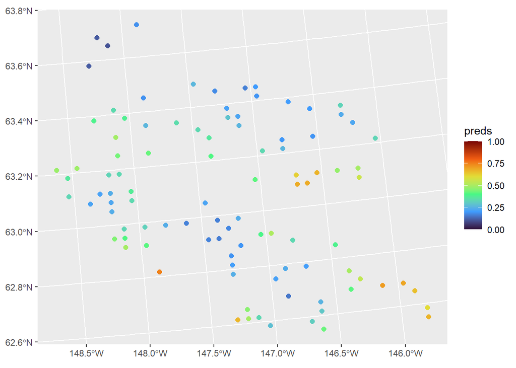

```r
ggplot(moose_preds, aes(color = preds)) +
  geom_sf(size = 2) +
  scale_color_viridis_c(limits = c(0, 1), option = "H")
```

These predictions have similar spatial patterns as moose presence the observed data. Next we remove the model predictions from `moose_preds` and show how `augment()` can be used to obtain the same predictions alongside prediction intervals (on the response scale):

```r
moose_preds$preds <- NULL
augment(binmod, newdata = moose_preds, type.predict = "response", interval = "prediction")
```

```
#> Simple feature collection with 100 features and 5 fields
#> Geometry type: POINT
#> Dimension:     XY
#> Bounding box:  xmin: 269386.2 ymin: 1418453 xmax: 419976.2 ymax: 1541763
#> Projected CRS: NAD83 / Alaska Albers
#> # A tibble: 100 × 6
#>     elev strat .fitted .lower .upper           geometry
#>  * <dbl> <chr>   <dbl>  <dbl>  <dbl>        <POINT [m]>
#>  1  143. L       0.708 0.244   0.948 (401239.6 1436192)
#>  2  324. L       0.333 0.0351  0.872 (352640.6 1490695)
#>  3  158. L       0.257 0.0300  0.795 (360954.9 1491590)
#>  4  221. M       0.238 0.0339  0.736 (291839.8 1466091)
#>  5  209. M       0.748 0.269   0.960 (310991.9 1441630)
#>  6  218. L       0.187 0.0182  0.740 (304473.8 1512103)
#>  7  127. L       0.174 0.0210  0.675 (339011.1 1459318)
#>  8  122. L       0.237 0.0325  0.742 (342827.3 1463452)
#>  9  191  L       0.389 0.0396  0.908 (284453.8 1502837)
#> 10  105. L       0.493 0.110   0.885 (391343.9 1483791)
#> # ℹ 90 more rows
```

# 6 Function Glossary

Here we list some commonly used `spmodel` functions.

- `AIC()`: Compute the AIC.
- `AICc()`: Compute the AICc.
- `anova()`: Perform an analysis of variance.
- `augment()`: Augment data with diagnostics or new data with predictions.
- `AUROC()`: Compute the area under the receiver operating characteristic curve for binary spatial generalized linear models.
- `BIC()`: Compute the BIC.
- `coef()`: Return coefficients.
- `conditional()`: Generate many plausible random samples of model parameters and `newdata`.
- `confint()`: Compute confidence intervals.
- `cooks.distance()`: Compute Cook’s distance.
- `covmatrix()`: Return covariance matrices.
- `decorrelate()`, `decorrelate_data()`, `decorrelate_newdata()`, `recorrelate_newdata()`: Account for spatial dependence in machine learning algorithms via the spatial decorrelation transformation.
- `deviance()`: Compute the deviance.
- `eacf()`: Compute an empirical autocovariance.
- `esv()`: Compute an empirical semivariogram.
- `fitted()`: Compute fitted values.
- `glance()`: Glance at a fitted model.
- `glances()`: Glance at multiple fitted models.
- `hatvalues()`: Compute leverage (hat) values.
- `kcv()`: Perform k-fold cross validation.
- `logLik()`: Compute the log-likelihood.
- `loocv()`: Perform leave-one-out cross validation.
- `model.matrix()`: Return the model matrix ($\mathbf{X}$).
- `plot()`: Create fitted model plots.
- `predict()`: Compute predictions and prediction intervals.
- `pseudoR2()`: Compute the pseudo r-squared.
- `residuals()`: Compute residuals.
- `satterthwaite()`: Compute Satterthwaite degrees of freedom for fixed effect coefficients.
- `spautor()`: Fit a spatial linear model for areal data (i.e., spatial autoregressive model).
- `spautorRF()`: Fit a random forest spatial residual model for areal data.
- `spgautor()`: Fit a spatial generalized linear model for areal data (i.e., spatial generalized autoregressive model).
- `splm()`: Fit a spatial linear model for point-referenced data (i.e., geostatistical model).
- `splmRF()`: Fit a random forest spatial residual model for point-referenced data.
- `spglm()`: Fit a spatial generalized linear model for point-referenced data (i.e., generalized geostatistical model).
- `sprbeta()`: Simulate spatially correlated beta random variables.
- `sprbinom()`: Simulate spatially correlated binomial (Bernoulli) random variables.
- `sprgamma()`: Simulate spatially correlated gamma random variables.
- `sprinvgauss()`: Simulate spatially correlated inverse Gaussian random variables.
- `sprnbinom()`: Simulate spatially correlated negative binomial random variables.
- `sprnorm()`: Simulate spatially correlated normal (Gaussian) random variables.
- `sprpois()`: Simulate spatially correlated Poisson random variables.
- `summary()`: Summarize fitted models.
- `tidy()`: Tidy fitted models.
- `varcomp()`: Compare variance components.
- `vcov()`: Compute variance-covariance matrices of estimated parameters.

For a full list of `spmodel` functions alongside their documentation, see the documentation manual. Documentation for methods of generic functions that are defined outside of `spmodel` can be found by running `help("generic.spmodel", "spmodel")` (e.g., `help("summary.spmodel", "spmodel")`, `help("predict.spmodel", "spmodel")`, etc.). Note that `?generic.spmodel` is shorthand for `help("generic.spmodel", "spmodel")`.

# 7 Support for Additional **R** Packages

`spmodel` provides support for:

1. The `tidy()`, `glance()` and `augment()` functions from the `broom` **R** package (Robinson et al. 2021).
2. The `emmeans` **R** package (Lenth 2024) applied to `splm()`, `spautor()`, `spglm()`, and `spgautor()` model objects from `spmodel`.
3. Various other **R** functions including `formula()`, `model.frame()`, `update()`, `terms()`, `car::vif()`, `car::Anova()`, and `effects::predictorEffect()`.

# References

Lenth, Russell V. 2024. *emmeans: Estimated Marginal Means, Aka Least-Squares Means*. https://CRAN.R-project.org/package=emmeans.

Pebesma, Edzer. 2018. “Simple Features for R: Standardized Support for Spatial Vector Data.” *The R Journal* 10 (1): 439–46. https://doi.org/10.32614/RJ-2018-009.

Robinson, David, Alex Hayes, and Simon Couch. 2021. *broom: Convert Statistical Objects into Tidy Tibbles*. https://CRAN.R-project.org/package=broom.

Wickham, Hadley. 2016. *ggplot2: Elegant Graphics for Data Analysis*. Springer-Verlag. https://ggplot2.tidyverse.org.